# Analizando Tweets en R

### Graficar por frecuencia la cantidad de tweets

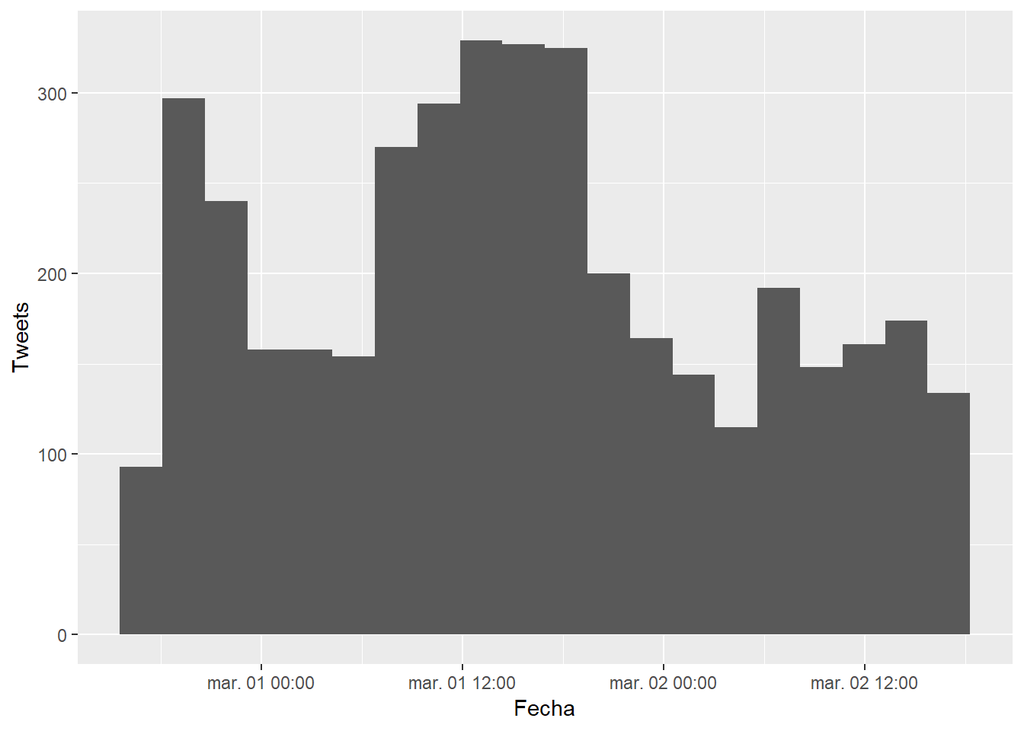

```r
ggplot(rt, aes(x = rt$created_at)) +
  geom_histogram(position = "identity", bins = 20, show.legend = FALSE)+
  ggplot2::labs(
    x = "Fecha", y="Tweets")
```

### Graficar por las diferentes fuente del tweet

Primero, con la función **filter** seleccionamos sólo aquellos que tienen en la columna source, la subcadena *“Twitter”* en algún lugar del texto.  
Después se agrupa con la función **grop_by** por la columna *source* (de las fuentes ya filtradas).  
Con la función **ts_plot** graficamos, en este caso por horas (*hours*).  
La función **facet_wrap** nos ayuda a dividir los gráficos por *source*.

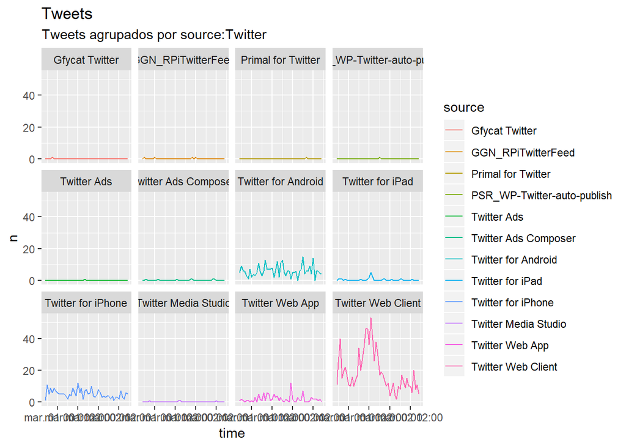

```r
rt %>%
  dplyr::filter(stringr::str_detect(source, "Twitter")) %>%
  dplyr::group_by(source) %>%
  ts_plot(., by = "hours") +
  facet_wrap(. ~ source) +
  ggplot2::labs(
    title = "Tweets",
    subtitle = "Tweets agrupados por source:Twitter"
  )
```

## Búsqueda por contenido

Para buscar por contenido es muy parecido a buscar por hashtag, sólo que esta vez buscará la palabra en todo el texto.

```r
rtAI <- search_tweets("Artificial Intelligence", n=5000)
```

```r
rt_analytics <- search_tweets("analytics", n = 250000, retryonratelimit = TRUE)
```

## Buscar por geo-localización, lookup_coords requiere un api de google maps

Debe tener una clave de Google maps, asigna la clave a una variable GOOGLEAPI

La función lookup_coords ayuda a encontrar las coordenadas de los tweets.

```r
rt_usa <- search_tweets(n = 1000,lang = "en", geocode = lookup_coords("usa", apikey =GOOGLEAPI), include_rts = FALSE)
```

```
## Searching for tweets...
```

```
## Finished collecting tweets!
```

Con la función lat_lng se calcula la latitud y longitud, a partir de las coordenadas anteriormente, creando dos columans más.

```r
rt_usa <- lat_lng(rt_usa)

rtAI <- lat_lng(rt)
```

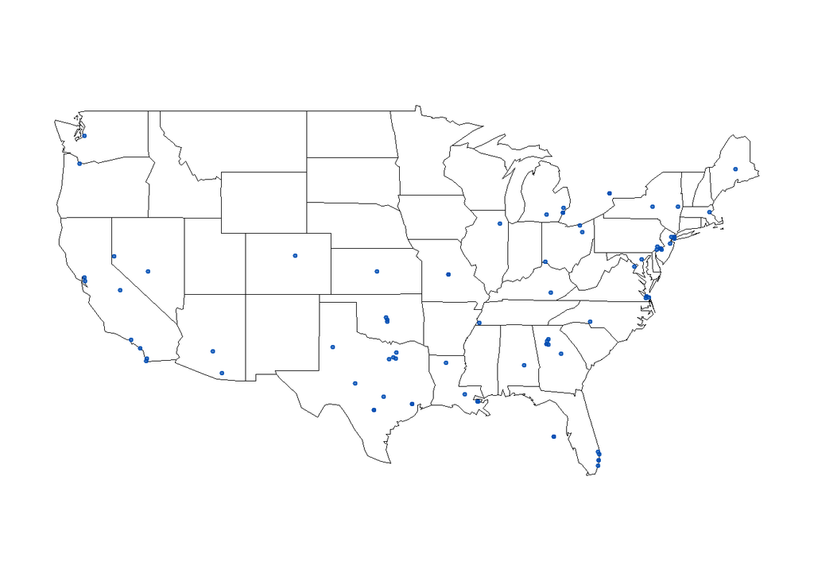

```r
par(mar = c(0, 0, 0, 0))
maps::map("state", lwd = .25)
with(rt_usa, points(lng, lat, pch = 20, cex = .75, col = rgb(0, .3, .7, .75)))
```

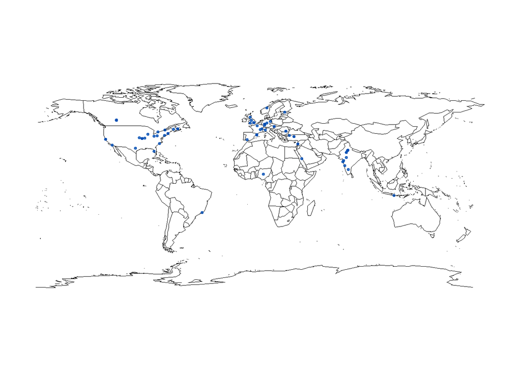

```r
par(mar = c(0, 0, 0, 0))
maps::map("world", lwd = .25)
with(rtAI, points(lng, lat, pch = 20, cex = .75, col = rgb(0, .3, .7, .75)))
```

## search_users

De manera similar, puede usar la función search_users() para buscar por usuarios. Esta función devuelve sólo un cuadro de datos de los usuarios e información sobre sus cuentas.

```r
usersM <- search_users("#Maduro",n = 500)
```

```
## Searching for users...
```

```
## Finished collecting users!
```

### Saber de dónde son los usuarios

```r
length(unique(usersM$location))
```

```
## [1] 253
```

```r
unique(usersM$location)
```

```
##   [1] "Venezuela"                      "Paris, France"
##   [3] "Venezuela (not really)"         ""
##   [5] "Chandler, AZ"                   "Rotterdam"
##   [7] "Neu-Ulm, Bayern"                "New York City"
##   [9] "Akute, Iju."                    "Washington, DC"
##  [11] "Panama"                         "Groningen, The Netherlands"
##  [13] "Leesburg, Virginia"             "Santa Cruz, Aruba"
##  [15] "Lexington, SC"                  "Toronto, Ontario"
##  [17] "London"                         "Nederland"
##  [19] "atlantis"                       "Curacao"
##  [21] "Orlando, FL"                    "Aruba"
##  [23] "Alicante, España"               "New York, NY"
##  [25] "venezuela"                      "Tampa, FL"
##  [27] "5835 Forward Avenue 15217"      "Bronx, NY"
##  [29] "City of Angeles"                "DC ↔ CT"
```

[output cut: 112 more lines]

## Visualizar los tweets por localización de los usuarios

[figure not shown]

```r
usersM %>%
  ggplot(aes(location)) +
  geom_bar() + coord_flip() +
      labs(x = "Count",
      y = "Location",
      title = "Cantidad de usuarios por localización")
```

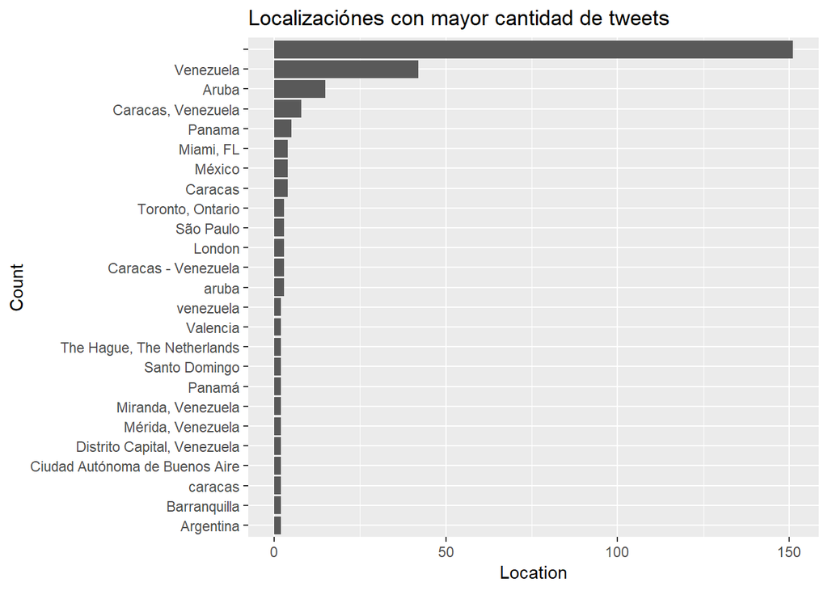

```r
usersM %>%
  count(location, sort = TRUE) %>%
  mutate(location = reorder(location, n)) %>%
  top_n(20) %>%
  ggplot(aes(x = location, y = n)) +
  geom_col() +
  coord_flip() +
      labs(x = "Count",
      y = "Location",
      title = "Localizaciónes con mayor cantidad de tweets")
```

## Contar frecuencia de palabras en el texto de los tweets

```r
if (!require(tidyverse)) install.packages("tidytext")
library(tidytext)
```

```r
hmtTable <- rtAI %>%
   unnest_tokens(word, text)
```

# Hacer tabla de frecuencia por palabras

```r
hmtTable <-hmtTable %>%
  count(word, sort = TRUE)
hmtTable
```

```
## # A tibble: 17,619 x 2
##    word                       n
##    <chr>                  <int>
##  1 t.co                    5618
##  2 https                   5616
##  3 artificialintelligence  4101
##  4 ai                      2947
##  5 the                     2192
##  6 to                      1679
##  7 and                     1293
##  8 of                      1266
##  9 machinelearning         1235
## 10 in                      1168
## # ... with 17,609 more rows
```

# Hacer nube de palabras

```r
if (!require(wordcloud2)) {install.packages("wordcloud2")}
library(wordcloud2)
```

```r
wordcloud2(hmtTable, size=0.7)
```

[interactive chart not shown]

## Descargar tweets en vivo

```r
rtlive <- stream_tweets()
```

```r
unique(rtlive$screen_name)
```

# Recupera la lista de cuentas que CanalRCN sigue.

```r
rcn_fds <- get_friends("CanalRCN")
## Datos de esa cuentas
rcn_fds_data <- lookup_users(rcn_fds$user_id)
```

## Recupera la lista de seguidores de una cuenta

```r
## Obtener user IDs de las cuentas de los seguidores de CanalRCN
rcn_flw <- get_followers("CanalRCN")

## Devuelve los datos de los las cuentas de estos usuarios
rcn_flw_data <- lookup_users(rcn_flw$user_id)
```

Cuáles son los seguidores de RCN que tiene más seguidores?

```r
rcn_flw_data %>%
  select(screen_name, followers_count, statuses_count) %>%
  arrange(desc(followers_count)) %>%
  top_n(10)
```

```
## # A tibble: 10 x 3
##    screen_name     followers_count statuses_count
##    <chr>                     <int>          <int>
##  1 hernanorjuela            241353          61516
##  2 mccr0                      7250          59111
##  3 LizardoGramcko             7111         634142
##  4 slabbebri                  3455          83751
##  5 Dayis_Jaramillo            1611          89260
##  6 OspinaPauce                1524          60221
##  7 JennRoa03                   902          48832
##  8 Limoncituuu                 834          56522
##  9 EstelaGomezGom2             744          70408
## 10 Beatriz20D                  539         117280
```

## Todos los seguidores (Tenga en cuenta que esto puede tomar un tiempo largo)

```r
#Cantidad de seguidores de
rcn <- lookup_users("CanalRCN")

## Obtener todos (esto puede tardar dias, dependiendo de la cuenta)
rcn_flw <- get_followers("CanalRCN", n = rcn$followers_count, retryonratelimit = TRUE)
```

## Get timelines

Obtener los más recientes tweets desde RCN y CaracolTV

```r
## IDs de cuentas seguidas por Caracol y RCN
tmls <- get_timelines(c("CanalRCN", "CaracolTV"), n = 3200)
```

## Graficar la frecuencia de tweets para cada usuario en el tiempo

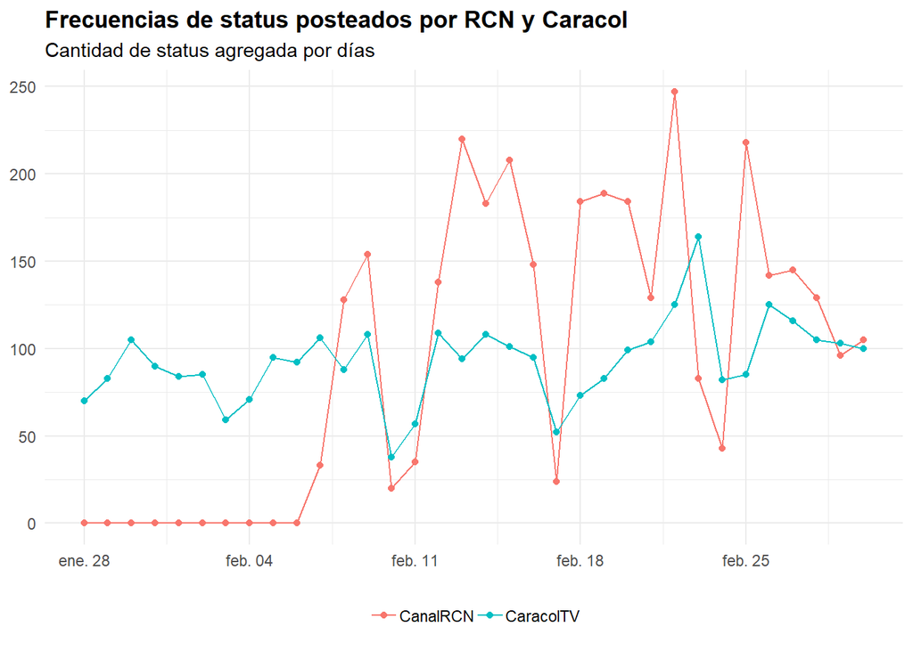

```r
tmls %>%
  dplyr::group_by(screen_name) %>%
  ts_plot("days", trim = 1L) +
  ggplot2::geom_point() +
  ggplot2::theme_minimal() +
  ggplot2::theme(
    legend.title = ggplot2::element_blank(),
    legend.position = "bottom",
    plot.title = ggplot2::element_text(face = "bold")) +
  ggplot2::labs(
    x = NULL, y = NULL,
    title = "Frecuencias de status posteados por RCN y Caracol",
    subtitle = "Cantidad de status agregada por días"
  )
```

## Guardar los tweets en un csv

```r
save_as_csv(rtAI, "tweetsAI")
```

## Recuperar los tweets guardados en el csv

```r
rtReadCSV<-read_twitter_csv("tweetsAI.csv")
```